# LAB_1

### F<sub>ST</sub> outliers

Sprawdźmy też, które SNP w poszczególnych genach najbardziej wpływają na róznicowanie się populacji. Jak wygląda ta pozycja w alignmecie? Spójrzmy na Gen 1.

```r
# Compute per-locus Fst along with other population genetic statistics
# - basic.stats() calculates various genetic diversity metrics per locus
# - The input is a hierfstat-formatted dataset (genind_hierf)
locus_stats <- basic.stats(genind_hierf)

# Extract per-locus Fst values from the computed statistics
# - locus_stats$perloc$Fst contains Fst values for each locus separately
locus_fst_values <- locus_stats$perloc$Fst

# Print the per-locus Fst values
locus_fst_values

# Identify the locus with the highest Fst value
# - which() finds the index of the locus with the maximum Fst value
FST_max_gene_1 <- which(locus_fst_values == max(locus_fst_values))

# Print the index of the locus with the highest Fst
FST_max_gene_1

# Identify segregating sites in the DNA alignment
# - seg.sites() finds variable positions in the DNA sequence alignment
seg_sites <- seg.sites(dna_tot)

# Visualize all segregating sites in the DNA alignment using a heatmap
# - image.DNAbin() creates a visual representation of sequence variation
image.DNAbin(dna_tot[, seg_sites])

# Visualize the segregating site corresponding to the highest Fst locus
# - This focuses on the site with the highest genetic differentiation
image.DNAbin(dna_tot[, seg_sites][, FST_max_gene_1])
```

Wyszukajmy locus (loci) z najwyższą wartością FST, zapiszemy wartość FST i pozycję tego SNP. Następnie prównanym przyrowannie wszystkich miejsc zmiennych i miejsca o najwyższym FST.

```
##  [1]  0.0037  0.0084  0.0000  0.0013  0.0000  0.0000  0.0000  0.0000  0.0013
## [10]  0.0037  0.0000  0.0013  0.0013  0.0000  0.0000  0.0000  0.0000  0.0000
## [19]  0.0000  0.0162 -0.0005  0.0175  0.0037  0.0000  0.0000
```

[output not shown]

```
## [1] 22
```

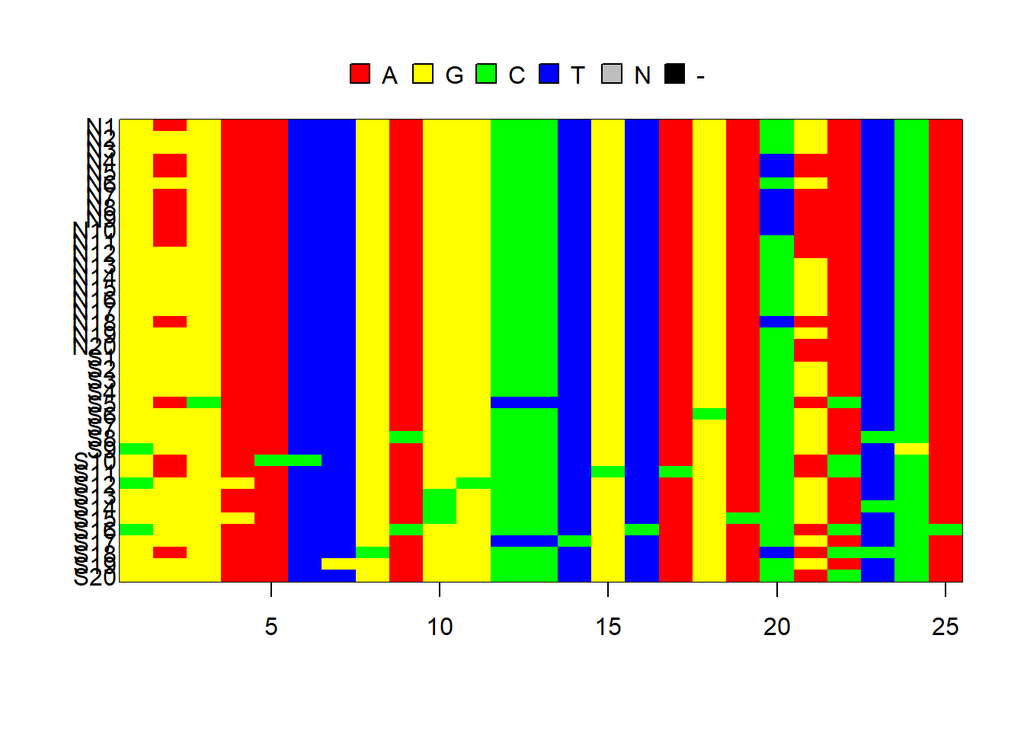

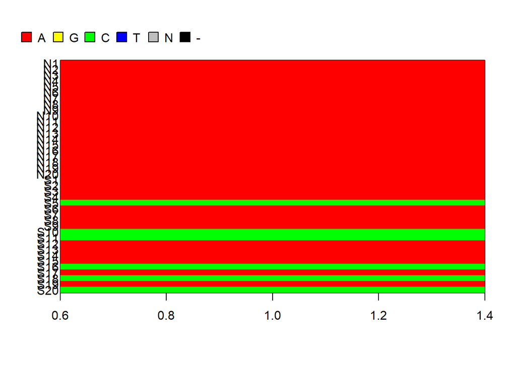

**Ćwiczenie 5**- Oblicz FST per locus dla każdego genu. Zapisz pozycję tego SNP i wartość FST spójrz na alignment dla każdego genu i SNP o najwyższym FST.

## Podsumowanie i wnioski

Posługując się całością informacji wstępnych i wynikami wszystkich przeprowadzonych analiz, uzasadnij dla którego z badanych genów jego zmienność genetyczna jest niezgodna z modelem ewolucji neutralnej. Na jakie typy selekcji wskazuje obraz zmienności w tym locus?

**Ćwiczenie 6**- Użyj narzędzia BLASThttps://blast.ncbi.nlm.nih.gov/Blast.cgi by wskazać produkt genu na który działa dobór naturalny i opisz krótko jego funkcje.